# DATA505 Final Model

Grad students vs. 7 evil models

Kaiona Apio & Jeffrey Smith

## Intro

- Predicting profit for CravenSpeed products using sales data and product features.

## Main Component Material

- Based on the distributions of the main material used in each product, Aluminum and Steel had the most products in the higher profit range.

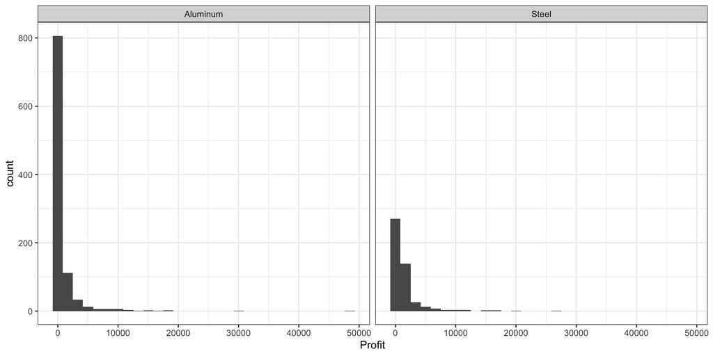

## Main Component MFG Process

- The manufacturing processes that most consistently saw products in the higher profit range were the Lathe and Form processes, so an indicator for these processes was included in the model.

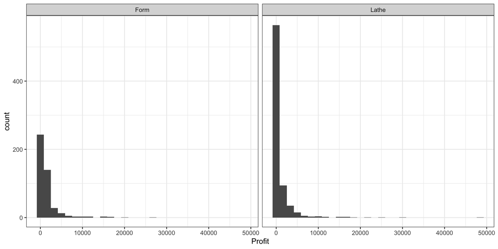

## Main Component Finishing Process

- Only one finishing process had consistent products with higher profits, so an indicator for that process `Powder` was included.

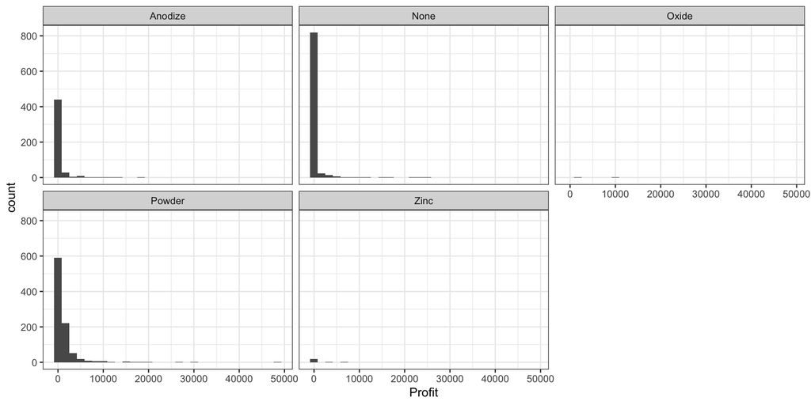